# Prosper Loan Data Analysis

## by Lynn Majerome

## Investigation Overview

> The main objective of the analysis is to examine the connections between different features in the Prosper loan dataset, including loan amount, interest rate, employment status, income range, and debt to income ratio.Through this analysis, we aim to uncover patterns and trends in the data and gain a better understanding of the characteristics of the loan data and the factors that may affect the borrower's interest rate.

## Dataset Overview

> The dataset being analyzed is a data set from Prosper Loan, a peer-to-peer lending lending company. The data includes features such as loan amount, borrower rate, employment status, income range, and debt to income ratio. The dataset can be found [here](https://www.kaggle.com/datasets/shikhar07/prosper-loan-data)

## Income Bracket

> The plot allows us to visualize the distribution of borrower income in the data set and gain insight into which income brackets are more represented among the borrowers. It gives us a clearer picture of the financial backgrounds of the borrowers in the data set.

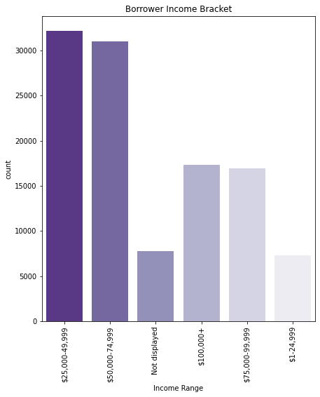

## Employment Status

> The plot shows the number of loans taken out by borrowers in each employment category. Most borrowers in this dataset are employed, followed by full-time, self-employed, and part-time. There are fewer borrowers who fall into the category retired. This information can be useful for understanding the employment status of the borrowers in the loan data and how it may affect their ability to make loan payments.

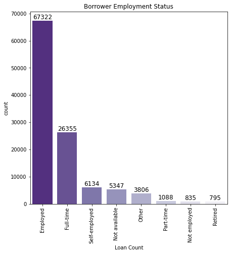

## Interest Rate according to Employment Status

> The violin plot displays the range of interest rates for each employment status, with the thicker part of the "violin" representing a higher density of data points. This allows us to see how the interest rates vary among the different employment statuses.

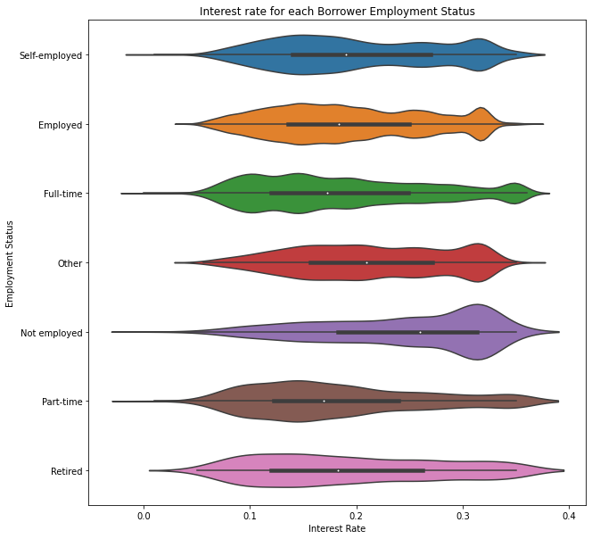

## Interest Rate according to Income Bracket

> The plot suggests that there is some variation in interest rates within each income bracket, with the range being wider for some income brackets compared to others. It also appears that borrowers in the lower income brackets tend to have higher interest rates on average compared to those in the higher income brackets.

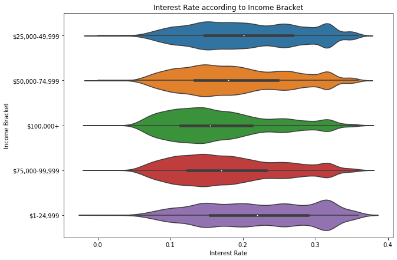

## Employment status, interest rate and homeownership

> The plot helps better understand the relationship between employment status, homeowner status, and interest rate in the loan data. By examining the plot, we can see the notable differences in the interest rates between the different employment status and homeowner status combinations.

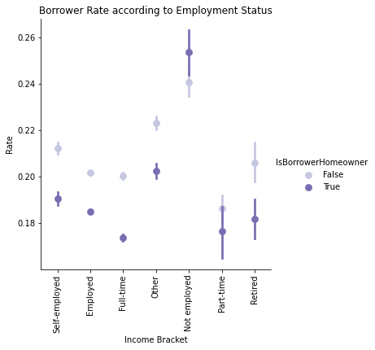